# Regression Portfolio

```r
## Libraries used throughout
library(ggplot2)
library(ggcorrplot)
```

## 1. Multiple Linear Regression

Dataset is from the *House Sales in King County, USA* Kaggle Dataset and can be found [here](https://www.kaggle.com/harlfoxem/housesalesprediction)

```r
## Getting the data
houseData <- read.csv(file.choose())

head(houseData)
```

```
##           id   price bedrooms bathrooms sqft_living sqft_lot floors waterfront
## 1 7129300520  221900        3      1.00        1180     5650      1          0
## 2 6414100192  538000        3      2.25        2570     7242      2          0
## 3 5631500400  180000        2      1.00         770    10000      1          0
## 4 2487200875  604000        4      3.00        1960     5000      1          0
## 5 1954400510  510000        3      2.00        1680     8080      1          0
## 6 7237550310 1230000        4      4.50        5420   101930      1          0
##   view condition grade sqft_above yr_built yr_renovated zipcode sqft_living15
## 1    0         3     7       1180     1955            0   98178          1340
## 2    0         3     7       2170     1951         1991   98125          1690
## 3    0         3     6        770     1933            0   98028          2720
## 4    0         5     7       1050     1965            0   98136          1360
## 5    0         3     8       1680     1987            0   98074          1800
## 6    0         3    11       3890     2001            0   98053          4760
##   sqft_lot15
## 1       5650
## 2       7639
## 3       8062
## 4       5000
## 5       7503
## 6     101930
```

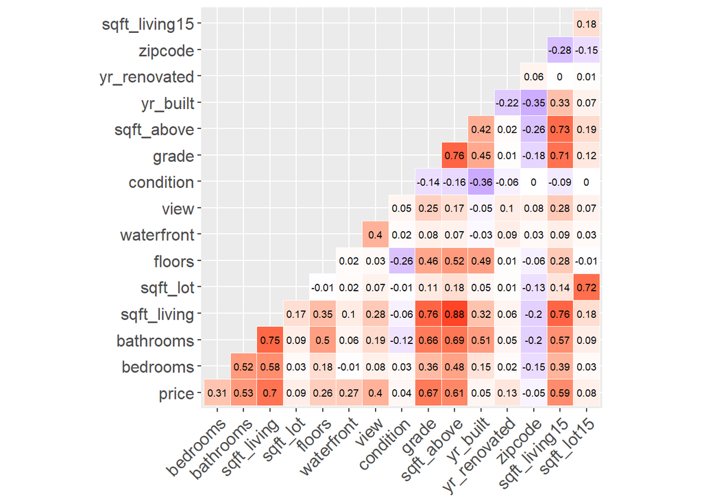

```r
## Correlation plot
corr <- round(cor(houseData[2:17]), 2)
ggcorrplot(
  corr,
  type="lower",
  lab=TRUE,
  lab_size=2.5,
  outline.col="white",
  show.legend=FALSE,
  ggtheme = ggplot2::theme_gray
)
```

#### Addressing Multicollinearity

1. Multicollinearity is defined as a condition where two or more predictors are highly correlated with one another. Consequences of multicollinearity can be the instability of coefficient estimates and an inaccurate estimate of the variance
2. As you can see from the correlation plot, there seems to be high correlation between sqft_living and bathrooms, sqft_above and sqft_living
3. The good news is that multicollinearity does not prevent you from obtaining precise predictions, and since this is the aim of our model we can continue without much worry

```r
## Developing a tentative model
initialModel <- lm(price ~  bedrooms + bathrooms + sqft_living + sqft_lot +
                     floors + waterfront + view + condition + grade +
                     sqft_above + yr_built + yr_renovated + zipcode +
                     sqft_living15, data=houseData)
summary(initialModel)
```

```
##
## Call:
## lm(formula = price ~ bedrooms + bathrooms + sqft_living + sqft_lot +
##     floors + waterfront + view + condition + grade + sqft_above +
##     yr_built + yr_renovated + zipcode + sqft_living15, data = houseData)
##
## Residuals:
##      Min       1Q   Median       3Q      Max
## -1330889  -109619    -9977    89866  4299435
##
## Coefficients:
##                 Estimate Std. Error t value Pr(>|t|)
## (Intercept)    6.186e+06  3.133e+06   1.975   0.0483 *
## bedrooms      -3.871e+04  2.031e+03 -19.056  < 2e-16 ***
## bathrooms      4.648e+04  3.497e+03  13.290  < 2e-16 ***
## sqft_living    1.665e+02  4.697e+00  35.452  < 2e-16 ***
## sqft_lot      -2.544e-01  3.676e-02  -6.921 4.61e-12 ***
## floors         2.821e+04  3.838e+03   7.349 2.06e-13 ***
## waterfront     5.777e+05  1.867e+04  30.948  < 2e-16 ***
## view           4.331e+04  2.289e+03  18.919  < 2e-16 ***
## condition      1.913e+04  2.525e+03   7.574 3.76e-14 ***
## grade          1.205e+05  2.257e+03  53.422  < 2e-16 ***
## sqft_above    -7.451e+00  4.590e+00  -1.623   0.1046
## yr_built      -3.598e+03  7.468e+01 -48.182  < 2e-16 ***
## yr_renovated   9.624e+00  3.926e+00   2.451   0.0142 *
## zipcode        5.861e-01  3.144e+01   0.019   0.9851
## sqft_living15  2.313e+01  3.651e+00   6.334 2.43e-10 ***
## ---
## Signif. codes:  0 '***' 0.001 '**' 0.01 '*' 0.05 '.' 0.1 ' ' 1
##
## Residual standard error: 216500 on 21598 degrees of freedom
## Multiple R-squared:  0.653,  Adjusted R-squared:  0.6528
## F-statistic:  2903 on 14 and 21598 DF,  p-value: < 2.2e-16
```

```r
## Creating a reduced model

reducedModel <- lm(price ~  bedrooms + bathrooms + sqft_living + sqft_lot +
                     floors + waterfront + view + condition + grade +
                     yr_built + sqft_living15, data=houseData)
summary(reducedModel)
```

```
##
## Call:
## lm(formula = price ~ bedrooms + bathrooms + sqft_living + sqft_lot +
##     floors + waterfront + view + condition + grade + yr_built +
##     sqft_living15, data = houseData)
##
## Residuals:
##      Min       1Q   Median       3Q      Max
## -1322708  -109674   -10555    89993  4304565
##
## Coefficients:
##                 Estimate Std. Error t value Pr(>|t|)
## (Intercept)    6.379e+06  1.302e+05  48.982  < 2e-16 ***
## bedrooms      -3.886e+04  2.027e+03 -19.165  < 2e-16 ***
## bathrooms      4.853e+04  3.419e+03  14.194  < 2e-16 ***
## sqft_living    1.617e+02  3.581e+00  45.143  < 2e-16 ***
## sqft_lot      -2.603e-01  3.640e-02  -7.152 8.83e-13 ***
## floors         2.601e+04  3.436e+03   7.571 3.85e-14 ***
## waterfront     5.792e+05  1.863e+04  31.094  < 2e-16 ***
## view           4.415e+04  2.238e+03  19.725  < 2e-16 ***
## condition      1.835e+04  2.462e+03   7.454 9.41e-14 ***
## grade          1.203e+05  2.240e+03  53.706  < 2e-16 ***
## yr_built      -3.665e+03  6.705e+01 -54.653  < 2e-16 ***
## sqft_living15  2.160e+01  3.523e+00   6.130 8.93e-10 ***
## ---
## Signif. codes:  0 '***' 0.001 '**' 0.01 '*' 0.05 '.' 0.1 ' ' 1
##
## Residual standard error: 216500 on 21601 degrees of freedom
## Multiple R-squared:  0.6529, Adjusted R-squared:  0.6527
## F-statistic:  3693 on 11 and 21601 DF,  p-value: < 2.2e-16
```

```r
## Partial F test
anova(initialModel, reducedModel)
```

```
## Analysis of Variance Table
##
## Model 1: price ~ bedrooms + bathrooms + sqft_living + sqft_lot + floors +
##     waterfront + view + condition + grade + sqft_above + yr_built +
##     yr_renovated + zipcode + sqft_living15
## Model 2: price ~ bedrooms + bathrooms + sqft_living + sqft_lot + floors +
##     waterfront + view + condition + grade + yr_built + sqft_living15
##   Res.Df        RSS Df   Sum of Sq      F  Pr(>F)
## 1  21598 1.0121e+15
## 2  21601 1.0125e+15 -3 -4.0471e+11 2.8788 0.03456 *
## ---
## Signif. codes:  0 '***' 0.001 '**' 0.01 '*' 0.05 '.' 0.1 ' ' 1
```

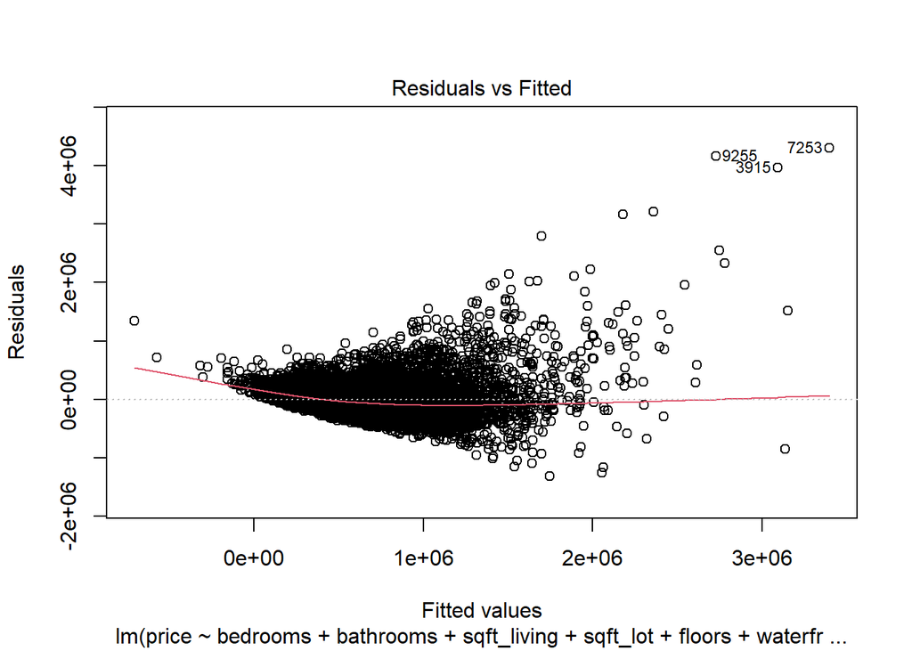

```r
## Residual Plot
plot(reducedModel, which=1)
```

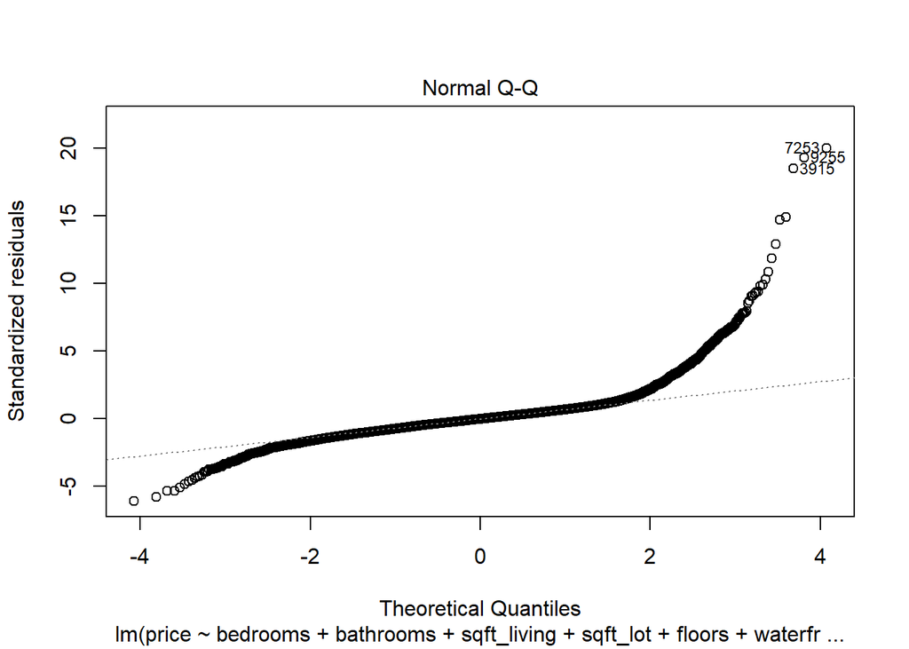

```r
## QQ Plot
plot(reducedModel, which=2)
```

#### Predictions

1. When doing predictions it is important that most of the time we not predict an X value that is outside of the range of X values that we have, this is called extrapolation.
   - This can quickly become a problem because we do not know how the data will act outside of the X values we have, and making a prediction on these unknown values could result in errors.

```r
## Creating the new hotel
## newHotel <- data.frame(area=55000, age=4, numrooms=319, OccRate=0.80)
## newHotel
```

```r
## Predicting the energy of the new hotel
## predict(finalModel, interval="predict", newdata=newHotel)
```

[output not shown]